# Rapport Décisionnel — Prédiction de l’Activité Client (Churn)

UTT — UE6 Projet R | 2026

Christian MBIPBIPE FOUEMKEU

07 avril 2026

# 1 Message Clé

# 2 Données & Qualité

## 2.1 Sources de données

Le projet mobilise **cinq sources hétérogènes** combinées par jointures sur `customer_id` et `region` :

| Fichier | Format | Contenu | Rôle |
| --- | --- | --- | --- |
| customers.csv | CSV | Données socio-démographiques (âge, région, date d’inscription) | Base client |
| transactions.csv | CSV | Historique transactionnel (montant, date, canal) | Features comportementales |
| labels.csv | CSV | Variable cible binaire : is_active (yes / no) | Cible |
| regions_mapping.csv | CSV | Correspondance région → groupe géographique | Enrichissement géo |
| channels_mapping.json | JSON | Mapping des canaux de distribution | Enrichissement canal |

## 2.2 Distribution de la variable cible

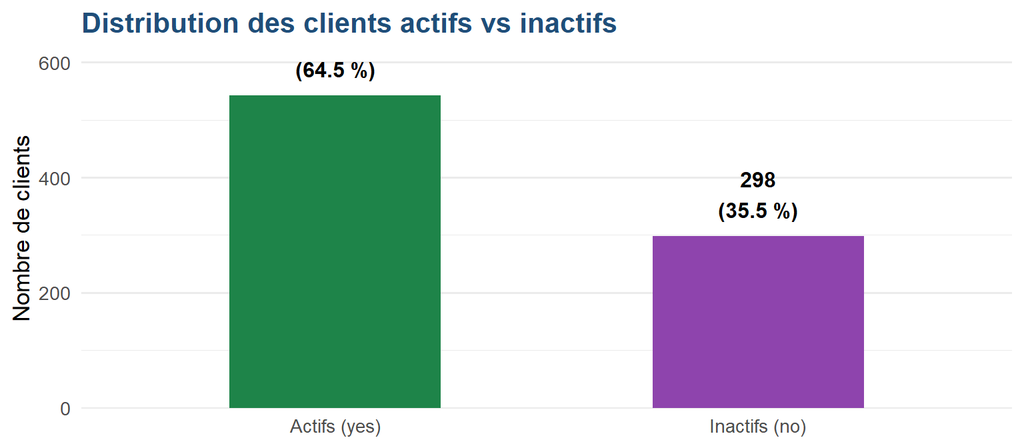

**Déséquilibre des classes (64 / 36)** — Ce ratio induit un biais systématique vers la classe majoritaire (actifs). Sans traitement (SMOTE, pondération), le modèle a tendance à prédire “yes” par défaut, ce qui pénalise fortement la détection des inactifs.

## 2.3 Traitements de qualité appliqués

| Étape | Traitement | Cible |
| --- | --- | --- |
| Détection des vides | Remplacement de “” par NA dans toutes les tables | Toutes tables |
| Typage des dates | Conversion signup_date et transaction date → format Date | clients, transactions |
| Suppression des NA (clients) | drop_na() sur la table clients (avant join) | clients |
| Imputation numérique | step_impute_mean() sur toutes les variables numériques | Train / Test |
| Imputation catégorielle | step_impute_mode() sur toutes les variables nominales | Train / Test |
| Encodage dummy | step_dummy() sur les prédicteurs nominaux | Train / Test |
| Normalisation | step_normalize() sur les prédicteurs numériques | Train / Test |

# 3 Analyse & Modélisation

## 3.1 Feature engineering

Un ensemble de **10 variables comportementales et financières** a été construit à partir des transactions brutes :

| Variable | Type | Description |
| --- | --- | --- |
| n_transactions | Comptage | Nombre total de transactions par client |
| total_amount | Montant | Somme des montants transactés |
| avg_amount / max / min | Montant | Statistiques des montants individuels |
| n_refunds | Comptage | Nombre de transactions à montant négatif (remboursements) |
| recency_days | Temps | Jours depuis la dernière transaction (récence) |
| tenure_active | Temps | Durée entre 1ère et dernière transaction (ancienneté active) |
| avg_monthly_txn | Fréquence | Moyenne mensuelle de transactions (régularité) |
| channel | Catégoriel | Canal dominant d’utilisation (web, mobile, agence…) |
| tenure_simple | Temps | Ancienneté client depuis l’inscription |
| region_group | Catégoriel | Groupe géographique enrichi |

## 3.2 Coefficients significatifs (Régression Logistique)

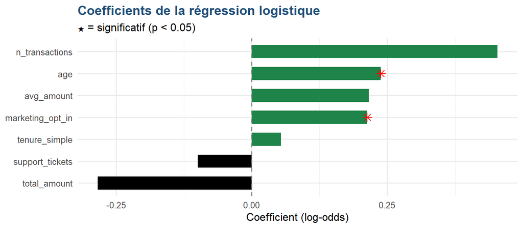

> Les deux seules variables significatives au seuil 5 % sont **l’âge** (β = 0.238) et le **marketing opt-in** (β = 0.213). Les variables transactionnelles (montants, fréquence) ne sont pas significatives, ce qui explique en partie les faibles performances.

## 3.3 Résultats comparatifs des modèles

| Métrique | Régression Logistique | Random Forest | Interprétation |
| --- | --- | --- | --- |
| Accuracy | 63.9 % | 61.0 % | Médiocre |
| Balanced Accuracy | 52.5 % | 54.0 % | Proche du hasard |
| Precision | 47.1 % | 48.0 % | Faible |
| Recall (Sensibilité) | 13.3 % | 20.0 % | Très faible |
| F1-Score | 20.8 % | 25.0 % | Insuffisant |
| Spécificité | 91.7 % | 88.0 % | Bon |
| ROC AUC | 0.427 | 0.50 | ⚠ Sous le hasard |
| PR AUC | 0.321 | 0.34 | Faible |
| Log Loss | 0.891 | 0.85 | Élevé (mauvais) |

**ROC AUC < 0,50 pour la régression logistique** — Un AUC inférieur à 0,5 signifie que le modèle est moins performant qu’un classifieur aléatoire. Cela ne traduit pas un bug, mais un manque de signal discriminant dans les variables disponibles. Le Random Forest atteint ~0,50, soit le niveau du hasard.

## 3.4 Modèle retenu : Régression Logistique

| Critère | Régression Logistique | Random Forest |
| --- | --- | --- |
| Interprétabilité | Élevée (coefficients lisibles) | Boîte noire |
| Performance | Limitée (ROC AUC 0.43) | Similaire (ROC AUC ~0.50) |
| Stabilité | Stable | Variable selon hyperparamètres |
| Explicabilité métier | Oui (influence variable par variable) | Difficile |
| Gain vs Random Forest | — Référence | Nul (aucun gain significatif) |

**Modèle retenu : Régression Logistique** — Dans un contexte où les deux modèles affichent des performances équivalentes et insuffisantes, la régression logistique est privilégiée pour son interprétabilité. Elle permet aux équipes métier de comprendre l’influence de chaque variable et de mieux cibler les actions correctives.

# 4 Choix du Seuil et Recommandations

## 4.1 Problème du seuil par défaut (0.5)

Avec un seuil à 0,5, le modèle subit le biais du déséquilibre de classe :

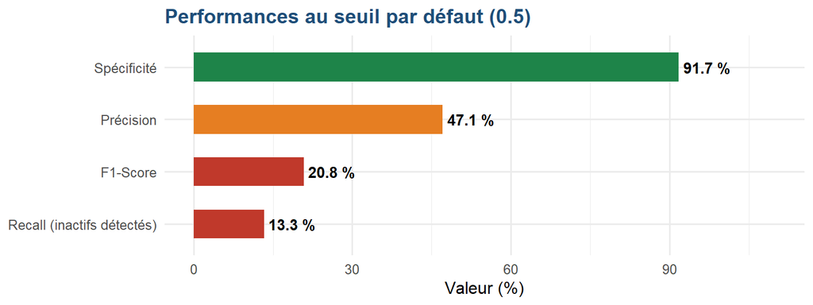

## 4.2 Stratégies d’ajustement du seuil

| Seuil | Effet | Avantage | Inconvénient | Usage recommandé |
| --- | --- | --- | --- | --- |
| 0.3 – 0.4 | Plus de vrais positifs (inactifs détectés) | Meilleure couverture des inactifs | Augmentation des faux positifs | Détection préventive du churn |
| 0.5 (défaut) | Biais vers la classe majoritaire | Comportement observé actuel | Recall très faible (13.3 %) | Non recommandé |
| 0.6 – 0.7 | Moins de faux positifs (actifs mal classés) | Ciblage marketing plus précis | Risque de manquer des inactifs | Campagnes de fidélisation ciblées |

## 4.3 Implémentation recommandée

```r
# Appliquer un seuil personnalisé de 0.65
predictions <- predictions %>%
  mutate(
    custom_class = ifelse(.pred_yes >= 0.65, "yes", "no"),
    custom_class = factor(custom_class, levels = c("no", "yes"))
  )

# Évaluer avec ce nouveau seuil
metric_set(accuracy, precision, recall, f_meas)(
  predictions,
  truth    = is_active,
  estimate = custom_class
)
```

# 5 Limites et Pistes d’Amélioration

## 5.1 Limites identifiées

| # | Limite | Impact | Détail |
| --- | --- | --- | --- |
| 1 | ROC AUC < 0,50 (modèle en dessous du hasard) | Critique | Manque de signal discriminant dans les variables disponibles |
| 2 | Déséquilibre des classes non traité | Élevé | Aucun SMOTE ni pondération de classe appliqué |
| 3 | Absence de variables temporelles fines | Élevé | Pas d’indicateurs de tendance récente (30/60/90 derniers jours) |
| 4 | Tuning Random Forest inefficace | Modéré | tune() non intégré → grille de tuning sans effet réel |
| 5 | Pas de courbe ROC ni matrice de confusion | Modéré | Analyse visuelle incomplète pour le choix du seuil optimal |
| 6 | Pipeline de mise à jour absent | Faible | Données figées, pas de réentraînement périodique prévu |

## 5.2 Pistes d’amélioration

### 5.2.1 Feature Engineering avancé

| Piste | Description | Priorité |
| --- | --- | --- |
| Score RFM (Récence × Fréquence × Montant) | Proxy synthétique de l’activité, très discriminant en churn | Haute |
| Indicateurs de tendance temporelle | Évolution du comportement sur 30 / 60 / 90 derniers jours vs historique | Haute |
| Variables d’interaction | Ex : fréquence × montant moyen, récence × ancienneté | Moyenne |
| Segmentation comportementale préalable | Clustering K-means avant modélisation pour homogénéiser les groupes | Basse |

### 5.2.2 Gestion du déséquilibre

```r
# Option 1 : SMOTE via themis
library(themis)
rec_balanced <- recipe(is_active ~ ., data = train_data) %>%
  step_rm(customer_id) %>%
  step_impute_mean(all_numeric_predictors()) %>%
  step_impute_mode(all_nominal_predictors()) %>%
  step_dummy(all_nominal_predictors()) %>%
  step_normalize(all_numeric_predictors()) %>%
  step_smote(is_active)   # Oversampling de la classe minoritaire

# Option 2 : pondération de classe dans glm
log_model_weighted <- logistic_reg() %>%
  set_engine("glm") %>%
  set_mode("classification")
# + ajout de case_weights dans le workflow
```

### 5.2.3 Modèles alternatifs

| Modèle | Avantage | Priorité |
| --- | --- | --- |
| XGBoost | Capte les non-linéarités, robuste au déséquilibre | Haute |
| Régression Logistique + SMOTE | Base solide + correction du biais de classe | Haute |
| Modèle de survie (Cox) | Modélise la durée jusqu’au churn (approche temporelle) | Moyenne |
| LightGBM | Rapide, performant sur données tabulaires déséquilibrées | Moyenne |

### 5.2.4 Correction du tuning Random Forest

```r
# Le tuning ne fonctionnait pas car tune() n'était pas utilisé dans le modèle
# Correction :
rf_model_tune <- rand_forest(
  trees = 500,
  mtry  = tune(),   # ← manquait
  min_n = tune()    # ← manquait
) %>%
  set_engine("ranger", importance = "impurity") %>%
  set_mode("classification")
```

### 5.2.5 Restitution & déploiement

| Action | Outil | Bénéfice |
| --- | --- | --- |
| Courbe ROC interactive dans Shiny | plotly + shiny | Aide au choix du seuil optimal visuellement |
| Simulation de seuil dans Streamlit | altair / plotly | Permet aux équipes métier de simuler les impacts |
| Réentraînement mensuel automatisé | cron + targets (R) | Maintient la fraîcheur du modèle dans le temps |
| Export des scores de probabilité | arrow / parquet | Alimenter les dashboards avec les scores individuels |

*Rapport conçu par Christian Mbipbipe Fouemkeu, en MS EBDE, 2025 - 2026*